# Analyse des avis et alertes ANSSI — Visualisation & Machine Learning

### DBSCAN

Détection des CVE atypiques combinant CVSS élevé et EPSS élevé.  
Contrairement à K-Means, DBSCAN isole les outliers (label = −1) et découvre le nombre de clusters automatiquement.  
Paramètre `eps=1.0` retenu via le k-distance graph.

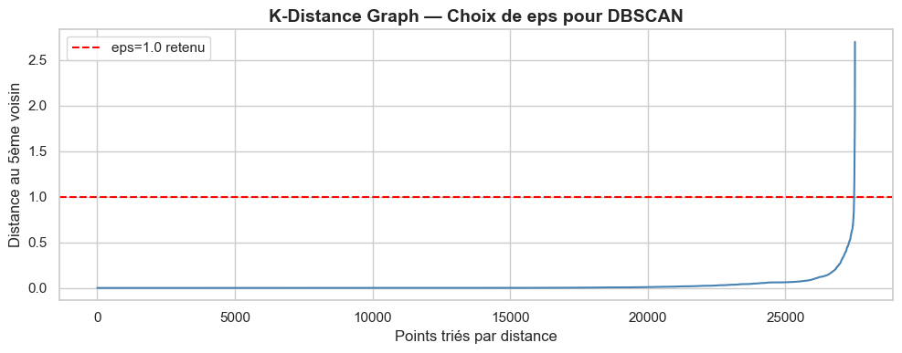

```
Clusters détectés : 5
Anomalies isolées : 21 (0.1%)

Profil moyen par cluster :
                cvss_score  epss_score
cluster_dbscan
-1                   7.733       0.475
 0                   6.571       0.024
 1                   8.960       0.921
 2                   7.529       0.050
 3                   8.216       0.117
 4                   0.000       0.007

Sévérité dominante par cluster :
cluster_dbscan
-1        High
 0        High
 1    Critical
 2        High
 3        High
 4         Low
Name: base_severity, dtype: object

=== Top 10 CVE les plus dangereux (cluster 1 + anomalies) ===
        cve_id  cvss_score  epss_score base_severity     vendor
CVE-2023-35078        10.0     0.94482      Critical     Ivanti
 CVE-2022-1388         9.8     0.94456      Critical         F5
CVE-2022-40684         9.8     0.94427      Critical   Fortinet
CVE-2023-35082        10.0     0.94423      Critical     Ivanti
CVE-2024-21887         9.1     0.94412      Critical     Ivanti
CVE-2021-38647         9.8     0.94392      Critical  Microsoft
CVE-2023-46805         8.2     0.94367          High     Ivanti
CVE-2021-26855         9.1     0.94351      Critical  Microsoft
 CVE-2023-4966         9.4     0.94348      Critical     Citrix
CVE-2024-24919         8.6     0.94342          High checkpoint
```

```python
# --- K-Distance Graph pour choisir eps ---
nbrs      = NearestNeighbors(n_neighbors=5).fit(X_clu_scaled)
distances, _ = nbrs.kneighbors(X_clu_scaled)
distances = np.sort(distances[:, 4])

plt.figure(figsize=(10, 4))
plt.plot(distances, color='steelblue', linewidth=1.5)
plt.axhline(y=1.0, color='red', linestyle='--', linewidth=1.5, label='eps=1.0 retenu')
plt.title("K-Distance Graph — Choix de eps pour DBSCAN",
          fontsize=14, fontweight='bold')
plt.xlabel("Points triés par distance", fontsize=12)
plt.ylabel("Distance au 5ème voisin", fontsize=12)
plt.legend()
plt.tight_layout()
plt.show()

# --- DBSCAN final eps=1.0 ---
dbscan = DBSCAN(eps=1.0, min_samples=5)
df_connus['cluster_dbscan'] = dbscan.fit_predict(X_clu_scaled)

n_clusters  = len(set(df_connus['cluster_dbscan']) - {-1})
n_anomalies = (df_connus['cluster_dbscan'] == -1).sum()

print(f"Clusters détectés : {n_clusters}")
print(f"Anomalies isolées : {n_anomalies} ({n_anomalies/len(df_connus)*100:.1f}%)")

print("\nProfil moyen par cluster :")
print(df_connus.groupby('cluster_dbscan')[['cvss_score', 'epss_score']]
      .mean().round(3))

print("\nSévérité dominante par cluster :")
print(df_connus.groupby('cluster_dbscan')['base_severity']
      .apply(lambda x: x.value_counts().index[0]))

# --- Top CVE dangereux détectés ---
print("\n=== Top 10 CVE les plus dangereux (cluster 1 + anomalies) ===")
dangereux = df_connus[df_connus['cluster_dbscan'].isin([-1, 1])]\
            .sort_values('epss_score', ascending=False)
print(dangereux[['cve_id', 'cvss_score', 'epss_score',
                 'base_severity', 'vendor']].head(10).to_string(index=False))
```

*Le k-distance graph trace, pour chaque point, la distance à son 5ème voisin le plus proche, triée par ordre croissant. La courbe reste quasi nulle jusqu'à environ 25 000 points, révélant une zone dense où la quasi-totalité des CVE forment un cœur compact. L'explosion brutale au-delà de ce seuil identifie les points isolés — les outliers. La ligne rouge (eps=1.0) est positionnée au niveau du "coude" de cette montée, permettant à DBSCAN de distinguer la masse dense des anomalies sans les englober dans un cluster. Ce choix produit 5 clusters cohérents et 21 anomalies représentant les CVE aux profils atypiques.*

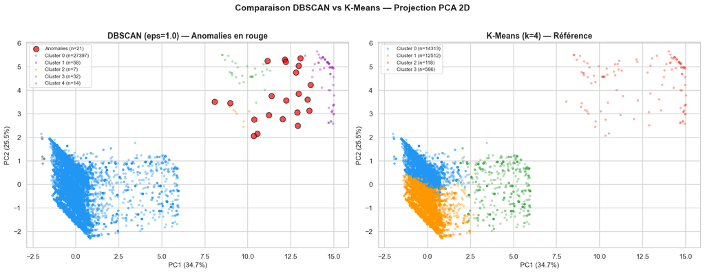

```python
fig, axes = plt.subplots(1, 2, figsize=(16, 6))

palette_dbscan = {
    -1: '#FF0000', 0: '#2196F3', 1: '#9C27B0',
     2: '#FF9800', 3: '#4CAF50', 4: '#607D8B'
}

for label, color in palette_dbscan.items():
    mask = df_connus['cluster_dbscan'] == label
    if not mask.any():
        continue
    nom  = "Anomalies" if label == -1 else f"Cluster {label}"
    axes[0].scatter(X_pca[mask, 0], X_pca[mask, 1],
                    c=color, label=f"{nom} (n={mask.sum()})",
                    alpha=0.7 if label == -1 else 0.4,
                    s=80 if label == -1 else 15,
                    edgecolors='black' if label == -1 else 'none',
                    zorder=5 if label == -1 else 1)

axes[0].set_title("DBSCAN (eps=1.0) — Anomalies en rouge",
                  fontsize=13, fontweight='bold')
axes[0].set_xlabel(f"PC1 ({variance[0]:.1%})", fontsize=11)
axes[0].set_ylabel(f"PC2 ({variance[1]:.1%})", fontsize=11)
axes[0].legend(fontsize=8, loc='upper left')

for i in range(K_FINAL):
    mask = df_connus['cluster_kmeans'] == i
    axes[1].scatter(X_pca[mask, 0], X_pca[mask, 1],
                    c=colors_km[i], label=f'Cluster {i} (n={mask.sum()})',
                    alpha=0.4, s=15, edgecolors='none')

axes[1].set_title("K-Means (k=4) — Référence",
                  fontsize=13, fontweight='bold')
axes[1].set_xlabel(f"PC1 ({variance[0]:.1%})", fontsize=11)
axes[1].set_ylabel(f"PC2 ({variance[1]:.1%})", fontsize=11)
axes[1].legend(fontsize=8, loc='upper left')

plt.suptitle("Comparaison DBSCAN vs K-Means — Projection PCA 2D",
             fontsize=14, fontweight='bold', y=1.02)
plt.tight_layout()
plt.show()
```